# Examen2

Examen 2

- Nombre: Carlos Felipe Niño Rodríguez.
- Email: cfnino@unbosque.edu.co
- Big Data Analytics.
- Profesor: Fabian Peña.
- Universidad el bosque.

Buenos días, profesor, siento que en el taller 2 no me fue del todo bien por eso intente hacer este examen capturando también la imagen del presidente de la misma página y mostrarla en el dataframe creado.

```python
# Importing required libraries
import time
import requests
import pandas as pd
from bs4 import BeautifulSoup
from selenium import webdriver
from IPython.core.display import HTML
```

```python
# Base URL of the site to be analyzed
SITE_URL = 'https://es.wikipedia.org/wiki/Anexo:Presidentes_de_Colombia'
```

```python
# Firefox web driver path
# Download the driver for you S.O. here: https://github.com/mozilla/geckodriver/releases
DRIVER_PATH = './geckodriver.exe'
```

```python
# Creating a new firefox window
browser = webdriver.Firefox(executable_path = DRIVER_PATH)
```

Obtenemos el contenido HTML de la página:

```python
browser.get(SITE_URL)
soup = BeautifulSoup(browser.page_source, 'html.parser')
```

Analizando el HTML de la página encontramos que las tablas de Wikipedia para esta página son así:

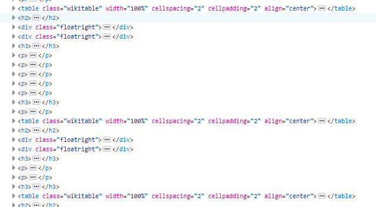

En esta parte buscamos el tag de tipo table, y que su clase se llame wikitable:

```python
tables = soup.find_all('table', class_ = 'wikitable')
```

Creamos un arreglo llamado blocks para poder buscar los tags de tr dentro de cada resultado de tables.

```python
blocks = []
for i in tables:
    blocks.append(i.find_all('tr'))

print("Cantidad de tablas: "+ str(len(blocks)))
```

```
Cantidad de tablas: 6
```

Podemos observar la cantidad encontrada de tags tr por cada tabla, esto haría referencia a cada presidente (tr referencia a las filas de la tabla).

**Nota:** El primer tr de cada tabla no contiene información.

```python
print("Cantidad de tr por tabla: ")
for b in range(0,len(blocks)):
    t = b+1
    print(str(t)+'-'+str(len(blocks[b])))
```

```
Cantidad de tr por tabla:
1-21
2-10
3-14
4-4
5-25
6-58
```

Analizando las tablas se observa que todos contienen las mismas columnas excepto la primera tabla de todas, que contiene una columna demás, por esta razón sacamos los títulos de la primera tabla para trabajar con estos títulos en general.

Para esta parte buscamos los tag th que hacen referencia a los títulos.

```python
headers = blocks[0][0].find_all('th')
titles = []
for h in headers:
    title = h.text.strip()
    titles.append(title)
titles
```

```
['Período', 'Efigie', 'Presidente', 'Ciudades', 'Alineación', 'Comentarios']
```

En esta parte vamos a recorrer todos los elementos de blocks, que es la lista de tags de tr, y vamos a buscar los td que sería cada columna de esa fila, almacenando el resultado en una variable content.

Luego vamos a recorrer content, para poder obtener los datos y guardarlos en una lista llamada con, esta lista hace referencia a un presidente.

Tenemos otra lista llamada cons, para poder guardar cada presidente.

```python
cons = []
for b in range(0, len(blocks)):
    for r in range(1,len(blocks[b])):
        content = blocks[b][r].find_all('td')
        con = []
        for c in range(0, len(content)):
            if(c != 0):
                # Como estamos utilizando los títulos de la primera tabla, significa que nos falta
                # una columna por rellenar para las siguientes tablas, por esta razón validamos que estemos
                # en una tabla diferente a la primera y agregamos un campo vacío antes de la columna 4 que haría referencia al título de ciudades.
                if(c == 4 and b!=0):
                    con.append('')
                    con.append(content[c].text.strip())
                else:
                    # Para la columna dos está la imagen del presidente por esta razón volvemos a buscar un tag
                    # que hace referencia a la imagen, el tag que buscamos es img y obtenemos el valor src de este tag
                    if(c == 2):
                        img = content[c].find_all('img')
                        # Validamos si tiene información
                        if(len(img) > 0):
                            con.append(img[0]['src'])
                        else:
                            con.append('')
                    else:
                        con.append(content[c].text.strip())
        cons.append(con)
# Creamos el dataframe con los datos capturados y los títulos.
df = pd.DataFrame(cons, columns=titles)
```

Para mostrar todas las filas del dataframe y mostrar toda la información de las columnas:

```
pd.set_option(“max_colwidth”, None)
pandas.set_option('display.max_rows', df.shape[0]+1)
```

Lo quite para que no quede tan extenso.

En esta parte movemos las columnas a la posición que deseamos y cambiamos el nombre de dos columnas.

```python
df = df[['Presidente','Efigie','Período','Alineación','Ciudades','Comentarios']]
df = df.rename(columns={'Efigie':'Foto','Alineación':'Partido político'})
df
```

|  | Presidente | Foto | Período | Partido político | Ciudades | Comentarios |
| --- | --- | --- | --- | --- | --- | --- |
| 0 | (e) José Miguel Pey y Andrade (1er. periodo) | //upload.wikimedia.org/wikipedia/commons/thumb... | 25 de julio de 1810-1 de abril de 1811 | Centralista | Santafé | Origen del mando: Encargo.\nPresidente de la J... |
| 1 | Jorge Tadeo Lozano | //upload.wikimedia.org/wikipedia/commons/thumb... | 1 de abril de 1811-19 de septiembre de 1811 | Federalista | Santafé | Origen del mando: Elegido.\nPresidente del Est... |
| 2 | Antonio José de Nariño y Álvarez | //upload.wikimedia.org/wikipedia/commons/thumb... | 30 de septiembre de 1813-29 de agosto de 1815 | Centralista | Santafé | Origen del mando: Elegido tras la renuncia de ... |
| 3 | Pedro Groot y Alea | //upload.wikimedia.org/wikipedia/commons/thumb... | 23 de diciembre de 1811 -24 de diciembre de 1811 | Centralista | Santafé | Presidente provisional de las Provincias Unida... |
| 4 | (e) Manuel Benito de Castro Arcaya | //upload.wikimedia.org/wikipedia/commons/thumb... | 25 de junio de 1812-5 de agosto de 1812 | Centralista | Santafé | Origen del mando: Encargado al asumir Nariño l... |
| ... | ... | ... | ... | ... | ... | ... |
| 121 | Ernesto Samper Pizano | //upload.wikimedia.org/wikipedia/commons/thumb... | 24 de enero de 1998-7 de agosto de 1998 | Liberal |  | Reasumió en enero de 1998. |
| 122 | Andrés Pastrana Arango | //upload.wikimedia.org/wikipedia/commons/thumb... | 7 de agosto de 1998-7 de agosto de 2002 | Nueva Fuerza Democrática - Conservador |  | Vicepresidente: Gustavo Bell.Hijo de Misael Pa... |
| 123 | Álvaro Uribe Vélez (1er y 2do periodo) | //upload.wikimedia.org/wikipedia/commons/thumb... | 7 de agosto de 2002-7 de agosto de 2010 | Primero Colombia |  | Vicepresidente: Francisco Santos Calderón.\nFu... |
| 124 | Juan Manuel Santos Calderón (1er y 2do periodo) | //upload.wikimedia.org/wikipedia/commons/thumb... | 7 de agosto de 2010-7 de agosto de 2018 | Partido Social de Unidad Nacional |  | Sobrino nieto de Eduardo Santos y descendiente... |
| 125 | Iván Duque Márquez | //upload.wikimedia.org/wikipedia/commons/thumb... | 7 de agosto de 2018-Actualmente en el cargo | Centro Democrático |  | Vicepresidenta: Marta Lucía Ramírez, primera m... |

126 rows × 6 columns

Eliminamos la columna de ciudades ya que en las tablas de Wikipedia solo la primera contaba con esta información, pero las otras 5 tablas de presidentes no la tenían, por esta razón decidí eliminar esta columna.

```python
df2 = df.drop(['Ciudades'],axis=1)
df2
```

|  | Presidente | Foto | Período | Partido político | Comentarios |
| --- | --- | --- | --- | --- | --- |
| 0 | (e) José Miguel Pey y Andrade (1er. periodo) | //upload.wikimedia.org/wikipedia/commons/thumb... | 25 de julio de 1810-1 de abril de 1811 | Centralista | Origen del mando: Encargo.\nPresidente de la J... |
| 1 | Jorge Tadeo Lozano | //upload.wikimedia.org/wikipedia/commons/thumb... | 1 de abril de 1811-19 de septiembre de 1811 | Federalista | Origen del mando: Elegido.\nPresidente del Est... |
| 2 | Antonio José de Nariño y Álvarez | //upload.wikimedia.org/wikipedia/commons/thumb... | 30 de septiembre de 1813-29 de agosto de 1815 | Centralista | Origen del mando: Elegido tras la renuncia de ... |
| 3 | Pedro Groot y Alea | //upload.wikimedia.org/wikipedia/commons/thumb... | 23 de diciembre de 1811 -24 de diciembre de 1811 | Centralista | Presidente provisional de las Provincias Unida... |
| 4 | (e) Manuel Benito de Castro Arcaya | //upload.wikimedia.org/wikipedia/commons/thumb... | 25 de junio de 1812-5 de agosto de 1812 | Centralista | Origen del mando: Encargado al asumir Nariño l... |
| ... | ... | ... | ... | ... | ... |
| 121 | Ernesto Samper Pizano | //upload.wikimedia.org/wikipedia/commons/thumb... | 24 de enero de 1998-7 de agosto de 1998 | Liberal | Reasumió en enero de 1998. |
| 122 | Andrés Pastrana Arango | //upload.wikimedia.org/wikipedia/commons/thumb... | 7 de agosto de 1998-7 de agosto de 2002 | Nueva Fuerza Democrática - Conservador | Vicepresidente: Gustavo Bell.Hijo de Misael Pa... |
| 123 | Álvaro Uribe Vélez (1er y 2do periodo) | //upload.wikimedia.org/wikipedia/commons/thumb... | 7 de agosto de 2002-7 de agosto de 2010 | Primero Colombia | Vicepresidente: Francisco Santos Calderón.\nFu... |
| 124 | Juan Manuel Santos Calderón (1er y 2do periodo) | //upload.wikimedia.org/wikipedia/commons/thumb... | 7 de agosto de 2010-7 de agosto de 2018 | Partido Social de Unidad Nacional | Sobrino nieto de Eduardo Santos y descendiente... |
| 125 | Iván Duque Márquez | //upload.wikimedia.org/wikipedia/commons/thumb... | 7 de agosto de 2018-Actualmente en el cargo | Centro Democrático | Vicepresidenta: Marta Lucía Ramírez, primera m... |

126 rows × 5 columns

Para la parte de las imagenes me guie de este repositorio: [github.com/Tanu-N-Prabhu](https://github.com/Tanu-N-Prabhu/Python/blob/master/Rendering_Images_inside_a_Pandas_DataFrame.ipynb)

```python
def path_to_image_html(path):
    return '<img src="'+ path + '" width="200" height="200" >'
```

```python
df2.to_html(escape=False, formatters=dict(Foto=path_to_image_html))
HTML(df2.to_html(escape=False,formatters=dict(Foto=path_to_image_html)))
```

|  | Presidente | Foto | Período | Partido político | Comentarios |
| --- | --- | --- | --- | --- | --- |
| 0 | (e) José Miguel Pey y Andrade (1er. periodo) |  | 25 de julio de 1810-1 de abril de 1811 | Centralista | Origen del mando: Encargo.\nPresidente de la Junta Suprema de Santafé de Bogotá tras la dimisión del Virrey Amar y Borbón. |
| 1 | Jorge Tadeo Lozano |  | 1 de abril de 1811-19 de septiembre de 1811 | Federalista | Origen del mando: Elegido.\nPresidente del Estado de Cundinamarca y Vicerregente de Nueva Granada.Vicepresidente: José María Domínguez del Castillo.\nFamiliaː Hijo del primer marqués de San Jorge\nMur… |
| 2 | Antonio José de Nariño y Álvarez |  | 30 de septiembre de 1813-29 de agosto de 1815 | Centralista | Origen del mando: Elegido tras la renuncia de Jorge Tadeo Lozano.\nPresidente del Estado de Cundinamarca.\nFue el prócer que más años pasó en prisión. |
| 3 | Pedro Groot y Alea |  | 23 de diciembre de 1811 -24 de diciembre de 1811 | Centralista | Presidente provisional de las Provincias Unidas de la Nueva Granada |
| 4 | (e) Manuel Benito de Castro Arcaya |  | 25 de junio de 1812-5 de agosto de 1812 | Centralista | Origen del mando: Encargado al asumir Nariño la campaña del Sur.\nPresidente del Estado de Cundinamarca; Consejero de Estado. |
| 5 | (e) Juan Dionisio Gamba y Ureña |  | 6 de noviembre de 1812-14 de diciembre de 1812 | Centralista | Origen del mando: Encargado por el general Antonio Nariño en su ausencia.\nPresidente del Estado de Cundinamarca. |
| 6 | Camilo Torres Tenorio (1er. periodo) |  | 27 de octubre de 1812-5 de octubre de 1814 | Federalista | Origen del mando: Elegido\nPresidente del Congreso de las Provincias Unidas.\nMurió fusilado bajo la Reconquista. |
| 7 | Manuel de Bernardo Álvarez del Casal |  | 29 de agosto de 1813-12 de diciembre de 1814 | Centralista | Origen del mando: Elegido.\nPresidente del Estado de Cundinamarca; al final de su gobierno, Cundinamarca fue incorporada a las Provincias Unidas\nFamiliaː Tío de Antonio Nariño, murió fusilado bajo la… |
| 8 | (e) José María Del Castillo y Rada |  | 5 de octubre de 1814-21 de enero de 1815 | Federalista | Origen del mando: Encargo.\nPresidente del Triunvirato de las Provincias Unidas. |
| 9 | José Joaquín Camacho y Rodríguez |  | 5 de octubre de 1814-21 de enero de 1815 | Federalista | Origen del mando: Encargo.\nMiembro del Triunvirato de las Provincias Unidas.\nMurió fusilado bajo la Reconquista. |
| 10 | (e) José Fernández Madrid (1er. periodo) |  | 5 de octubre de 1814-21 de enero de 1815 | Federalista | Origen del mando: Encargo.\nMiembro del Triunvirato de las Provincias Unidas. |
| 11 | Custodio García Rovira (1er. periodo) |  | 28 de noviembre de 1814-28 de marzo de 1815 | Centralista | Origen del mando: Elegido.\nPresidente del Triunvirato de las Provincias Unidas.\nMurió fusilado bajo la Reconquista. |
| 12 | (e) José Miguel Pey (2.° periodo) |  | 28 de marzo de 1815-28 de julio de 1815 | Centralista | Origen del mando: Encargo.\nPresidente del Triunvirato de las Provincias Unidas. |
| 13 | Manuel Rodríguez Torices |  | 28 de julio de 1815-17 de agosto de 1815 | Centralista | Origen del mando: Elegido.\nPresidente del Triunvirato de las Provincias Unidas.\nMurió fusilado bajo la Reconquista. |
| 14 | (e) Antonio Villavicencio y Verástegui |  | 17 de agosto de 1815-15 de noviembre de 1815 | Federalista | Origen del mando: Encargo.\nFamiliaː Hijo del conde del Real Agrado.\nMurió fusilado bajo la Reconquista. |
| 15 | Camilo Torres Tenorio (2.° periodo) |  | 15 de noviembre de 1815-22 de junio de 1816 | Federalista | Origen del mando: Elegido.\nVicepresidente: Manuel Rodríguez Torices |
| 16 | (e) José Fernández Madrid (2do. periodo) |  | 14 de marzo de 1816-22 de junio de 1816 | Federalista | Origen del mando: Encargado tras renuncia de Camilo Torres.\nEjerció en Popayán durante la reconquista española, tras la toma de Santafé de Bogotá.\nMurió fusilado bajo la ese régimen. |
| 17 | Custodio García Rovira (2do. periodo) |  | 22 de junio de 1816-19 de julio de 1816 | Centralista | Origen del mando: Elegido.\nEjerció en la provincia del Socorro durante la reconquista española.\nMurió fusilado bajo la ese régimen. |
| 18 | (e) Liborio Mejía Gutiérrez |  | 30 de junio de 1816-16 de julio de 1816 | Centralista | Origen del mando: Encargo.\nLa persona más joven en la historia del país en ocupar la presidencia (24 años).\nEjerció en Popayán durante la reconquista española. |
| 19 | Fernando Serrano Uribe |  | 16 de julio de 1816-16 de septiembre de 1816 | Centralista | Origen del mando: Elegido.\nEjerció en Casanare durante la reconquista española. |
| 20 | Simón Bolívar y Palacios (1er. periodo) |  | 21 de septiembre de 1819-20 de noviembre de 1819 | Centralista | Origen de mando: Triunfo militar, posteriormente elegido por el Congreso de Cúcuta.\nVicepresidente: Francisco de Paula Santander y Domingo Caycedo.\nEn ausencia de Bolívar, Santander asumió la presid… |
| 21 | (e) Francisco de Paula Santander y Omaña (1er. periodo) |  | 20 de noviembre de 1819-20 de febrero de 1827 | Federalista | Presidente, encargado del Poder Ejecutivo.\nVicepresidente: Antonio Nariño, fallecido en diciembre de 1823. |
| 22 | Simón Bolívar (2.° periodo) |  | 20 de febrero de 1827-4 de mayo de 1830 | Centralista | Estanislao Vergara Sanz de Santamaría\nOcupó la presidencia de la Gran Colombia del 28 de diciembre de 1828 al 15 de enero de 1830.\nRepuesto en el cargo y elegido dictador de la Gran Colombia.\nGuerr… |
| 23 | Domingo Caycedo y Santamaría (1er. periodo - delegado) |  | 4 de mayo de 1830-13 de junio de 1830 | Centralista | Origen del mando: Vicepresidente.\nSancionó la Constitución de 1830 que nunca rigió debido a la disolución de la Gran Colombia.\nAnte la ausencia del electo presidente Mosquera, el general Caycedo asu… |
| 24 | Joaquín Mosquera y Arboleda (1er. periodo) |  | 13 de junio de 1830-4 de septiembre de 1830 | Centralista | Elegido por el Congreso luego de la renuncia de Simón Bolívar en mayo de 1830.\nAsumió el gobierno al llegar a Santafé en junio.\nFamiliaː Hermano del general Tomás Cipriano de Mosquera |
| 25 | Rafael José Urdaneta Farías |  | 4 de septiembre de 1830-30 de abril de 1831 | Centralista | Noveno presidente, venezolano.\nFamiliaː Primo del militar uruguayo Francisco Urdaneta. |
| 26 | Ejecutivo Plural:\nJosé Miguel Pey y Andrade\nJerónimo de Mendoza Galavís\nJuan García Del Río |  | 30 de abril de 1831-2 de mayo de 1831 | Centralistas |  |
| 27 | Joaquín Mosquera y Arboleda (2do. periodo) |  | 2 de mayo de 1831-3 de mayo de 1831 | Centralista | Depuesto por su vicepresidente Domingo Caycedo. |
| 28 | Domingo Caycedo y Santamaría (2do. periodo) |  | 3 de mayo de 1831-23 de noviembre de 1831 | Centralista | Origen del mando: Vicepresidente. |
| 29 | José María Obando del Campo (1er. periodo) |  | 23 de noviembre de 1831-10 de marzo de 1832 | Federalista | Origen del mandoː Vicepresidente provisional |

[output cut: 96 more lines]